# Data Science Capstone - Next Word Prediction Shiny App

4/25/2021

## Description (Slide 1)

The Next Word Prediction Shiny App is designed to take text input provided by the user and produce a table of predicted next words. The application was trained on a corpus of approximately 2.5 million lines of text sourced from blogs, news articles and twitter entries.

## Instructions (Slide 2)

The Next Word Prediction Shiny App [[link]](https://sachaen.shinyapps.io/NextWordPrediction/) loads in a browser window and provides a text box for user entry. As the user types a phrase, the application will dynamically predict a set of predicted next possible words and present them in a data grid below.

## Prediction Algorithm (Slide 3)

In order to build a model that was sufficiently compact and responsive enough to be used in a Shiny App, the Stupid Back-Off Model based on quad-grams derived from the training data set was used. The model was filtered to the 70% of most common quad-grams for size. Each prediction produces the top 5 possible matches for the next word.

## Sample Predictions (Slide 4)

Some sample predictions

```r
predict(predictionModel, "Please hand me a can of")
```

```
## [1] "beer"   "food"   "course" "black"  "red"
```

```r
predict(predictionModel, "Would you like to go to the")
```

```
## [1] "beach"    "store"    "hospital" "next"     "park"
```

```r
predict(predictionModel, "I hope you have a great")
```

```
## [1] "day"     "weekend" "week"    "time"    "night"
```

## Application Interface (Slide 5)

A preview of the application

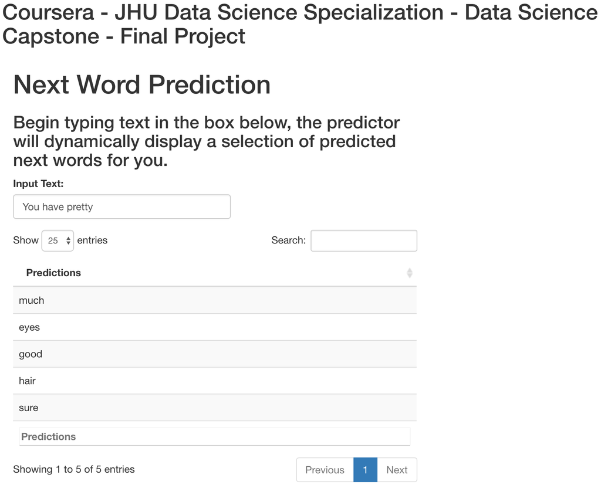

Application Preview